# League of Legends High Elo Ranked Games - Exploratory Data Analysis

```python
df_merged.tail()
```

|  | gameId | gameDuraton | blueWins | blueFirstBlood | blueFirstTower | blueFirstBaron | blueFirstDragon | blueFirstInhibitor | blueDragonKills | blueBaronKills | blueTowerKills | blueInhibitorKills | blueWardPlaced | blueWardkills | blueKills | blueDeath | blueAssist | blueChampionDamageDealt | blueTotalGold | blueTotalMinionKills | blueTotalLevel | blueAvgLevel | blueJungleMinionKills | blueKillingSpree | blueTotalHeal | blueObjectDamageDealt | redWins | redFirstBlood | redFirstTower | … |
| --- | --- | --- | --- | --- | --- | --- | --- | --- | --- | --- | --- | --- | --- | --- | --- | --- | --- | --- | --- | --- | --- | --- | --- | --- | --- | --- | --- | --- | --- | --- |
| 199831 | 4143231833 | 1468 | False | True | False | False | False | False | 1 | 0 | 0 | 0 | 72 | 20 | 24 | 28 | 50 | 99418 | 41437 | 438 | 60 | 12.0 | 106 | 8 | 20122 | 13309 | True | False | True | … |
| 199832 | 4157911901 | 970 | False | True | True | False | True | False | 3 | 0 | 5 | 1 | 37 | 2 | 29 | 42 | 36 | 61816 | 61221 | 346 | 65 | 13.0 | 28 | 5 | 32837 | 44640 | True | False | False | … |
| 199833 | 3764171638 | 1480 | False | True | True | False | True | False | 1 | 0 | 4 | 0 | 72 | 29 | 14 | 20 | 19 | 51604 | 45013 | 568 | 63 | 12.6 | 132 | 4 | 18131 | 45242 | True | False | False | … |
| 199834 | 4110201724 | 1837 | True | True | False | False | True | False | 3 | 0 | 5 | 0 | 91 | 25 | 32 | 19 | 66 | 93059 | 58160 | 640 | 76 | 15.2 | 168 | 7 | 75427 | 60486 | False | False | True | … |
| 199835 | 4100240254 | 948 | True | True | True | False | False | False | 1 | 0 | 4 | 0 | 35 | 11 | 10 | 2 | 19 | 22427 | 30001 | 399 | 50 | 10.0 | 89 | 3 | 10791 | 24827 | False | False | False | … |

```python
df_merged.sample(25)
```

|  | gameId | gameDuraton | blueWins | blueFirstBlood | blueFirstTower | blueFirstBaron | blueFirstDragon | blueFirstInhibitor | blueDragonKills | blueBaronKills | blueTowerKills | blueInhibitorKills | blueWardPlaced | blueWardkills | blueKills | blueDeath | blueAssist | blueChampionDamageDealt | blueTotalGold | blueTotalMinionKills | blueTotalLevel | blueAvgLevel | blueJungleMinionKills | blueKillingSpree | blueTotalHeal | blueObjectDamageDealt | redWins | redFirstBlood | redFirstTower | … |
| --- | --- | --- | --- | --- | --- | --- | --- | --- | --- | --- | --- | --- | --- | --- | --- | --- | --- | --- | --- | --- | --- | --- | --- | --- | --- | --- | --- | --- | --- | --- |
| 129497 | 4226113851 | 1589 | False | False | False | False | False | False | 0 | 0 | 2 | 0 | 61 | 22 | 21 | 31 | 40 | 69600 | 47920 | 546 | 62 | 12.4 | 106 | 6 | 30373 | 22509 | True | True | True | … |
| 137064 | 4243070458 | 928 | False | False | False | False | True | False | 1 | 0 | 0 | 0 | 42 | 10 | 6 | 19 | 6 | 27700 | 24065 | 361 | 45 | 9.0 | 72 | 0 | 9780 | 11536 | True | True | True | … |
| 109095 | 4218193535 | 1623 | False | False | False | True | False | False | 0 | 1 | 2 | 0 | 68 | 26 | 14 | 28 | 23 | 50665 | 46774 | 580 | 66 | 13.2 | 150 | 3 | 17033 | 23342 | True | True | True | … |
| 50954 | 4070578053 | 2137 | False | True | True | False | True | True | 4 | 0 | 10 | 2 | 70 | 28 | 44 | 38 | 67 | 145573 | 70259 | 629 | 81 | 16.2 | 273 | 8 | 52632 | 83576 | True | False | False | … |
| 89876 | 4218036753 | 1481 | True | False | False | True | True | False | 2 | 1 | 5 | 0 | 62 | 21 | 28 | 20 | 58 | 72513 | 50816 | 538 | 68 | 13.6 | 147 | 6 | 33288 | 45974 | False | True | True | … |
| 108360 | 4172031252 | 1648 | True | True | False | True | True | True | 4 | 1 | 8 | 1 | 92 | 28 | 29 | 14 | 55 | 66423 | 56102 | 639 | 73 | 14.6 | 146 | 7 | 30832 | 92857 | False | False | True | … |
| 74623 | 4034475824 | 2048 | False | False | False | False | True | False | 3 | 0 | 3 | 0 | 112 | 65 | 17 | 23 | 42 | 65554 | 57532 | 842 | 75 | 15.0 | 196 | 2 | 34045 | 34306 | True | True | True | … |
| 153743 | 4118846860 | 429 | True | True | True | False | False | True | 0 | 0 | 5 | 1 | 0 | 0 | 34 | 1 | 76 | 25576 | 22455 | 72 | 25 | 5.0 | 0 | 5 | 5505 | 37885 | False | False | False | … |
| 128258 | 4234312550 | 623 | True | True | True | False | True | True | 1 | 0 | 6 | 1 | 14 | 1 | 5 | 2 | 7 | 10157 | 21158 | 241 | 37 | 7.4 | 72 | 1 | 6418 | 27396 | False | False | False | … |
| 83920 | 4198616021 | 914 | True | True | True | False | True | False | 2 | 0 | 2 | 0 | 29 | 14 | 16 | 8 | 26 | 32247 | 31348 | 367 | 50 | 10.0 | 101 | 5 | 10886 | 31135 | False | False | False | … |
| 167355 | 3969649436 | 2308 | False | True | False | False | True | False | 1 | 1 | 4 | 0 | 137 | 39 | 37 | 36 | 65 | 127087 | 75568 | 840 | 87 | 17.4 | 187 | 9 | 60968 | 51563 | True | False | True | … |
| 183547 | 4236423355 | 1836 | False | False | False | False | False | False | 1 | 0 | 3 | 0 | 94 | 26 | 22 | 33 | 35 | 84410 | 56243 | 749 | 76 | 15.2 | 167 | 3 | 31676 | 21037 | True | True | True | … |
| 30398 | 4224002568 | 980 | True | False | True | False | True | False | 2 | 0 | 6 | 0 | 28 | 8 | 26 | 7 | 31 | 37254 | 35923 | 319 | 53 | 10.6 | 94 | 5 | 20737 | 32973 | False | True | False | … |
| 20085 | 4219463141 | 1749 | False | False | True | True | True | False | 2 | 1 | 2 | 0 | 73 | 35 | 24 | 33 | 30 | 83167 | 50491 | 556 | 70 | 14.0 | 121 | 4 | 18492 | 44798 | True | True | False | … |
| 139349 | 4214339132 | 602 | True | True | True | False | False | True | 0 | 0 | 6 | 1 | 14 | 0 | 7 | 1 | 2 | 9438 | 19787 | 198 | 34 | 6.8 | 48 | 2 | 5439 | 26225 | False | False | False | … |
| 116037 | 4156825343 | 1721 | False | False | True | False | False | False | 2 | 0 | 2 | 0 | 73 | 32 | 24 | 39 | 40 | 75415 | 55755 | 705 | 75 | 15.0 | 186 | 7 | 26851 | 45841 | True | True | False | … |
| 60047 | 4085285944 | 1660 | True | True | True | True | True | True | 3 | 1 | 11 | 3 | 70 | 25 | 40 | 22 | 50 | 99281 | 61511 | 567 | 72 | 14.4 | 176 | 9 | 32100 | 76641 | False | False | False | … |
| 157498 | 4075358225 | 1857 | False | False | True | False | False | False | 0 | 0 | 3 | 0 | 78 | 32 | 19 | 25 | 32 | 56993 | 52750 | 663 | 69 | 13.8 | 156 | 3 | 23310 | 27995 | True | True | False | … |
| 97716 | 4071900554 | 972 | True | False | True | False | True | True | 1 | 0 | 8 | 1 | 27 | 7 | 10 | 6 | 18 | 29478 | 32350 | 414 | 48 | 9.6 | 78 | 3 | 6468 | 37407 | False | True | False | … |
| 28896 | 4247197987 | 1078 | True | False | False | False | False | True | 0 | 0 | 4 | 2 | 0 | 0 | 47 | 38 | 105 | 111710 | 59928 | 217 | 87 | 17.4 | 0 | 15 | 25094 | 9654 | False | True | True | … |
| 125656 | 4226145886 | 1863 | True | True | True | True | False | True | 3 | 2 | 8 | 1 | 77 | 36 | 15 | 17 | 32 | 87202 | 62119 | 800 | 80 | 16.0 | 258 | 5 | 55448 | 102991 | False | False | False | … |
| 175163 | 4255910639 | 1302 | False | False | False | False | False | False | 0 | 0 | 1 | 0 | 54 | 11 | 12 | 39 | 16 | 42344 | 34610 | 412 | 53 | 10.6 | 76 | 1 | 20136 | 9070 | True | True | True | … |
| 60498 | 4229466430 | 2422 | False | False | True | False | False | True | 2 | 2 | 6 | 1 | 103 | 33 | 40 | 43 | 86 | 155770 | 77254 | 722 | 85 | 17.0 | 221 | 7 | 59854 | 95122 | True | True | False | … |
| 162813 | 4080121024 | 917 | False | False | False | False | False | False | 0 | 0 | 0 | 0 | 34 | 3 | 7 | 19 | 8 | 27286 | 21451 | 246 | 39 | 7.8 | 61 | 1 | 6500 | 1160 | True | True | True | … |
| 44184 | 4242524086 | 2307 | False | False | True | False | True | False | 3 | 0 | 3 | 0 | 89 | 35 | 32 | 40 | 47 | 121898 | 68225 | 778 | 82 | 16.4 | 234 | 8 | 47873 | 51067 | True | True | False | … |

> Now we export the combined dataframe to CSV so we that it'll be saved and we can use it for analysis.

```python
df_merged.to_csv(r'C:\Users\Liberty\Desktop\Master School\111 - Exploratory Data Analysis\High Elo Ranked Games.csv', index=False, header=True)
```

### Loading in newly merged csv file into a dataframe.

```python
# Checking to see if I can import the CSV file into a dataframe
df = pd.read_csv('High Elo Ranked Games.csv')
```

```python
df.head()
```

|  | gameId | gameDuraton | blueWins | blueFirstBlood | blueFirstTower | blueFirstBaron | blueFirstDragon | blueFirstInhibitor | blueDragonKills | blueBaronKills | blueTowerKills | blueInhibitorKills | blueWardPlaced | blueWardkills | blueKills | blueDeath | blueAssist | blueChampionDamageDealt | blueTotalGold | blueTotalMinionKills | blueTotalLevel | blueAvgLevel | blueJungleMinionKills | blueKillingSpree | blueTotalHeal | blueObjectDamageDealt | redWins | redFirstBlood | redFirstTower | … |
| --- | --- | --- | --- | --- | --- | --- | --- | --- | --- | --- | --- | --- | --- | --- | --- | --- | --- | --- | --- | --- | --- | --- | --- | --- | --- | --- | --- | --- | --- | --- |
| 0 | 4227123625 | 1429 | False | True | True | False | False | False | 0 | 0 | 4 | 0 | 75 | 33 | 7 | 19 | 13 | 42979 | 41910 | 646 | 60 | 12.0 | 180 | 2 | 15575 | 35335 | True | False | False | … |
| 1 | 4219545724 | 1313 | False | False | True | False | False | False | 0 | 0 | 3 | 0 | 45 | 13 | 6 | 22 | 9 | 36087 | 35880 | 563 | 56 | 11.2 | 119 | 1 | 13059 | 26348 | True | True | False | … |
| 2 | 4219463634 | 1660 | True | False | False | True | True | True | 1 | 1 | 9 | 2 | 66 | 31 | 30 | 13 | 61 | 64708 | 58214 | 651 | 74 | 14.8 | 209 | 7 | 37288 | 64577 | False | True | True | … |
| 3 | 4205778093 | 984 | True | True | True | False | True | False | 2 | 0 | 5 | 0 | 55 | 9 | 26 | 3 | 34 | 45772 | 36545 | 402 | 53 | 10.6 | 102 | 6 | 14093 | 31303 | False | False | False | … |
| 4 | 4201063474 | 1437 | False | True | True | False | True | False | 2 | 0 | 3 | 0 | 75 | 23 | 19 | 24 | 22 | 79501 | 42395 | 528 | 60 | 12.0 | 96 | 5 | 23863 | 30643 | True | False | False | … |

```python
df.tail()
```

|  | gameId | gameDuraton | blueWins | blueFirstBlood | blueFirstTower | blueFirstBaron | blueFirstDragon | blueFirstInhibitor | blueDragonKills | blueBaronKills | blueTowerKills | blueInhibitorKills | blueWardPlaced | blueWardkills | blueKills | blueDeath | blueAssist | blueChampionDamageDealt | blueTotalGold | blueTotalMinionKills | blueTotalLevel | blueAvgLevel | blueJungleMinionKills | blueKillingSpree | blueTotalHeal | blueObjectDamageDealt | redWins | redFirstBlood | redFirstTower | … |
| --- | --- | --- | --- | --- | --- | --- | --- | --- | --- | --- | --- | --- | --- | --- | --- | --- | --- | --- | --- | --- | --- | --- | --- | --- | --- | --- | --- | --- | --- | --- |
| 199831 | 4143231833 | 1468 | False | True | False | False | False | False | 1 | 0 | 0 | 0 | 72 | 20 | 24 | 28 | 50 | 99418 | 41437 | 438 | 60 | 12.0 | 106 | 8 | 20122 | 13309 | True | False | True | … |
| 199832 | 4157911901 | 970 | False | True | True | False | True | False | 3 | 0 | 5 | 1 | 37 | 2 | 29 | 42 | 36 | 61816 | 61221 | 346 | 65 | 13.0 | 28 | 5 | 32837 | 44640 | True | False | False | … |
| 199833 | 3764171638 | 1480 | False | True | True | False | True | False | 1 | 0 | 4 | 0 | 72 | 29 | 14 | 20 | 19 | 51604 | 45013 | 568 | 63 | 12.6 | 132 | 4 | 18131 | 45242 | True | False | False | … |
| 199834 | 4110201724 | 1837 | True | True | False | False | True | False | 3 | 0 | 5 | 0 | 91 | 25 | 32 | 19 | 66 | 93059 | 58160 | 640 | 76 | 15.2 | 168 | 7 | 75427 | 60486 | False | False | True | … |
| 199835 | 4100240254 | 948 | True | True | True | False | False | False | 1 | 0 | 4 | 0 | 35 | 11 | 10 | 2 | 19 | 22427 | 30001 | 399 | 50 | 10.0 | 89 | 3 | 10791 | 24827 | False | False | False | … |

```python
df.sample(10)
```

|  | gameId | gameDuraton | blueWins | blueFirstBlood | blueFirstTower | blueFirstBaron | blueFirstDragon | blueFirstInhibitor | blueDragonKills | blueBaronKills | blueTowerKills | blueInhibitorKills | blueWardPlaced | blueWardkills | blueKills | blueDeath | blueAssist | blueChampionDamageDealt | blueTotalGold | blueTotalMinionKills | blueTotalLevel | blueAvgLevel | blueJungleMinionKills | blueKillingSpree | blueTotalHeal | blueObjectDamageDealt | redWins | redFirstBlood | redFirstTower | … |
| --- | --- | --- | --- | --- | --- | --- | --- | --- | --- | --- | --- | --- | --- | --- | --- | --- | --- | --- | --- | --- | --- | --- | --- | --- | --- | --- | --- | --- | --- | --- |
| 109058 | 4129365664 | 2230 | False | False | False | False | False | False | 1 | 0 | 3 | 0 | 91 | 40 | 27 | 37 | 52 | 139501 | 65037 | 826 | 80 | 16.0 | 191 | 8 | 82499 | 40816 | True | True | True | … |
| 95844 | 4143198006 | 1951 | True | True | True | True | True | True | 4 | 1 | 11 | 2 | 86 | 52 | 43 | 23 | 32 | 97543 | 67704 | 742 | 83 | 16.6 | 227 | 9 | 53983 | 77473 | False | False | False | … |
| 177885 | 4173499667 | 1652 | True | True | True | True | True | True | 2 | 1 | 7 | 1 | 72 | 20 | 42 | 18 | 86 | 99404 | 57704 | 514 | 72 | 14.4 | 134 | 8 | 32957 | 82259 | False | False | False | … |
| 141714 | 4144271213 | 1773 | True | False | False | True | False | True | 1 | 1 | 7 | 1 | 74 | 39 | 26 | 26 | 53 | 84784 | 58289 | 678 | 75 | 15.0 | 140 | 7 | 26506 | 49338 | False | True | True | … |
| 191730 | 4074768456 | 1803 | False | True | False | False | True | False | 1 | 0 | 3 | 0 | 78 | 30 | 25 | 38 | 40 | 92526 | 53804 | 621 | 69 | 13.8 | 150 | 5 | 19492 | 15794 | True | False | True | … |
| 157560 | 4201712106 | 978 | False | False | False | False | False | False | 0 | 0 | 0 | 0 | 22 | 2 | 6 | 13 | 9 | 23658 | 26633 | 384 | 48 | 9.6 | 99 | 0 | 10239 | 4900 | True | True | True | … |
| 91437 | 3876205683 | 1017 | False | False | False | False | False | False | 0 | 0 | 0 | 0 | 29 | 4 | 6 | 21 | 7 | 25313 | 24672 | 340 | 42 | 8.4 | 79 | 1 | 5517 | 4085 | True | True | True | … |
| 195405 | 4085337272 | 952 | True | True | True | False | True | False | 2 | 0 | 3 | 0 | 36 | 10 | 21 | 8 | 27 | 39820 | 34061 | 423 | 52 | 10.4 | 90 | 4 | 15409 | 22951 | False | False | False | … |
| 60296 | 4225271615 | 977 | False | False | False | False | False | False | 0 | 0 | 0 | 0 | 35 | 9 | 5 | 15 | 4 | 22746 | 23298 | 350 | 46 | 9.2 | 76 | 1 | 10535 | 2877 | True | True | True | … |
| 80340 | 4198600491 | 1303 | True | True | True | True | True | False | 2 | 1 | 4 | 0 | 51 | 20 | 23 | 11 | 31 | 47762 | 43991 | 535 | 65 | 13.0 | 137 | 7 | 39746 | 43842 | False | False | False | … |

```python
df.shape
```

```
(199836, 51)
```

```python
df.describe()
```

|  | gameId | gameDuraton | blueDragonKills | blueBaronKills | blueTowerKills | blueInhibitorKills | blueWardPlaced | blueWardkills | blueKills | blueDeath | blueAssist | blueChampionDamageDealt | blueTotalGold | blueTotalMinionKills | blueTotalLevel | blueAvgLevel | blueJungleMinionKills | blueKillingSpree | blueTotalHeal | blueObjectDamageDealt | redDragonKills | redBaronKills | redTowerKills | redInhibitorKills | redWardPlaced | redWardkills | redKills | redDeath | redAssist | … |
| --- | --- | --- | --- | --- | --- | --- | --- | --- | --- | --- | --- | --- | --- | --- | --- | --- | --- | --- | --- | --- | --- | --- | --- | --- | --- | --- | --- | --- | --- | --- |
| count | 1.998360e+05 | 199836.000000 | 199836.000000 | 199836.000000 | 199836.000000 | 199836.000000 | 199836.000000 | 199836.000000 | 199836.000000 | 199836.000000 | 199836.000000 | 199836.000000 | 199836.000000 | 199836.000000 | 199836.000000 | 199836.000000 | 199836.000000 | 199836.000000 | 199836.000000 | 199836.000000 | 199836.000000 | 199836.000000 | 199836.000000 | 199836.000000 | 199836.000000 | 199836.000000 | 199836.000000 | 199836.000000 | 199836.000000 | … |
| mean | 4.165341e+09 | 1433.414670 | 1.356692 | 0.297719 | 4.343662 | 0.646935 | 53.436473 | 19.546118 | 24.720020 | 24.711383 | 40.384210 | 69494.585025 | 47925.147971 | 500.112052 | 64.712044 | 12.942409 | 123.912138 | 5.690616 | 24393.559189 | 37123.193404 | 1.519011 | 0.329690 | 4.275461 | 0.632999 | 53.560510 | 19.222042 | 24.623756 | 24.804204 | 40.242234 | … |
| std | 9.234478e+07 | 432.495698 | 1.254485 | 0.535049 | 3.377249 | 0.910003 | 30.364562 | 14.671816 | 13.540507 | 13.538179 | 29.138097 | 37439.865787 | 16068.788385 | 177.524086 | 14.815216 | 2.963043 | 65.997396 | 3.627792 | 15230.976780 | 26588.034157 | 1.307779 | 0.558929 | 3.392833 | 0.901577 | 30.592575 | 14.454102 | 13.524963 | 13.556007 | 29.036583 | … |
| min | 3.163679e+09 | 132.000000 | 0.000000 | 0.000000 | 0.000000 | 0.000000 | 0.000000 | 0.000000 | 0.000000 | 0.000000 | 0.000000 | 0.000000 | 3355.000000 | 0.000000 | 5.000000 | 1.000000 | 0.000000 | 0.000000 | 0.000000 | 0.000000 | 0.000000 | 0.000000 | 0.000000 | 0.000000 | 0.000000 | 0.000000 | 0.000000 | 0.000000 | 0.000000 | … |
| 25% | 4.136112e+09 | 1125.000000 | 0.000000 | 0.000000 | 1.000000 | 0.000000 | 33.000000 | 8.000000 | 15.000000 | 15.000000 | 20.000000 | 41600.000000 | 36539.000000 | 383.000000 | 55.000000 | 11.000000 | 83.000000 | 3.000000 | 13333.000000 | 13646.000000 | 0.000000 | 0.000000 | 1.000000 | 0.000000 | 33.000000 | 8.000000 | 15.000000 | 15.000000 | 20.000000 | … |
| 50% | 4.191586e+09 | 1420.000000 | 1.000000 | 0.000000 | 4.000000 | 0.000000 | 53.000000 | 18.000000 | 24.000000 | 24.000000 | 35.000000 | 64478.500000 | 47895.000000 | 515.000000 | 66.000000 | 13.200000 | 126.000000 | 5.000000 | 21325.000000 | 33121.000000 | 1.000000 | 0.000000 | 4.000000 | 0.000000 | 53.000000 | 18.000000 | 24.000000 | 24.000000 | 35.000000 | … |
| 75% | 4.222890e+09 | 1732.000000 | 2.000000 | 1.000000 | 7.000000 | 1.000000 | 73.000000 | 29.000000 | 33.000000 | 33.000000 | 54.000000 | 90887.250000 | 58822.000000 | 623.000000 | 75.000000 | 15.000000 | 169.000000 | 8.000000 | 32072.000000 | 56805.000000 | 2.000000 | 1.000000 | 7.000000 | 1.000000 | 73.000000 | 28.000000 | 33.000000 | 33.000000 | 54.000000 | … |
| max | 4.261026e+09 | 3758.000000 | 7.000000 | 4.000000 | 11.000000 | 9.000000 | 230.000000 | 118.000000 | 112.000000 | 117.000000 | 256.000000 | 381484.000000 | 134323.000000 | 1514.000000 | 141.000000 | 28.200000 | 402.000000 | 31.000000 | 261707.000000 | 167692.000000 | 7.000000 | 5.000000 | 11.000000 | 10.000000 | 248.000000 | 117.000000 | 116.000000 | 112.000000 | 229.000000 | … |

> Excellent! Now we can move on with our analysis.

### What is the structure of your dataset?

> The dataset consists of 199836 rows and 51 columns.

### What is/are the main feature(s) of interest in your dataset?

> The main features of interest in this dataset are the rank, red/bluewins, as well as well as the damagedealt columns. The truth is that this dataset provides a lot of information and we'll have to explore to better understand which features are most predictive of whether or not a team wins.

### What features in the dataset do you think will help support your investigation into your feature(s) of interest?

> The features that I believe will most help my investigation are the game duration, dragon kills, red/bluekills, and champion damage dealt.

## Univariate Exploration

```python
df.columns
```

```
Index(['gameId', 'gameDuraton', 'blueWins', 'blueFirstBlood', 'blueFirstTower',
       'blueFirstBaron', 'blueFirstDragon', 'blueFirstInhibitor',
       'blueDragonKills', 'blueBaronKills', 'blueTowerKills',
       'blueInhibitorKills', 'blueWardPlaced', 'blueWardkills', 'blueKills',
       'blueDeath', 'blueAssist', 'blueChampionDamageDealt', 'blueTotalGold',
       'blueTotalMinionKills', 'blueTotalLevel', 'blueAvgLevel',
       'blueJungleMinionKills', 'blueKillingSpree', 'blueTotalHeal',
       'blueObjectDamageDealt', 'redWins', 'redFirstBlood', 'redFirstTower',
       'redFirstBaron', 'redFirstDragon', 'redFirstInhibitor',
       'redDragonKills', 'redBaronKills', 'redTowerKills', 'redInhibitorKills',
       'redWardPlaced', 'redWardkills', 'redKills', 'redDeath', 'redAssist',
       'redChampionDamageDealt', 'redTotalGold', 'redTotalMinionKills',
       'redTotalLevel', 'redAvgLevel', 'redJungleMinionKills',
       'redKillingSpree', 'redTotalHeal', 'redObjectDamageDealt', 'rank'],
      dtype='object')
```

### 1. How many games of each rank do we have?

```python
df.groupby('rank').describe()
```

| rank | gameId count | gameId mean | gameId std | gameId min | gameId 25% | gameId 50% | gameId 75% | gameId max | gameDuraton count | gameDuraton mean | gameDuraton std | gameDuraton min | gameDuraton 25% | gameDuraton 50% | gameDuraton 75% | gameDuraton max | blueDragonKills count | blueDragonKills mean | blueDragonKills std | blueDragonKills min | blueDragonKills 25% | blueDragonKills 50% | blueDragonKills 75% | blueDragonKills max | blueBaronKills count | blueBaronKills mean | blueBaronKills std | blueBaronKills min | blueBaronKills 25% | … |
| --- | --- | --- | --- | --- | --- | --- | --- | --- | --- | --- | --- | --- | --- | --- | --- | --- | --- | --- | --- | --- | --- | --- | --- | --- | --- | --- | --- | --- | --- | --- |
| challenger | 26848.0 | 4.171908e+09 | 7.484765e+07 | 3.482433e+09 | 4.142424e+09 | 4.190650e+09 | 4.219681e+09 | 4.261026e+09 | 26848.0 | 1448.640793 | 422.580526 | 190.0 | 1152.75 | 1435.0 | 1738.0 | 3301.0 | 26848.0 | 1.389973 | 1.247234 | 0.0 | 0.0 | 1.0 | 2.0 | 7.0 | 26848.0 | 0.306987 | 0.537138 | 0.0 | 0.0 | … |
| grandmaster | 65876.0 | 4.172855e+09 | 7.890296e+07 | 3.191955e+09 | 4.144505e+09 | 4.194613e+09 | 4.224063e+09 | 4.257022e+09 | 65876.0 | 1427.946733 | 429.779613 | 132.0 | 1121.00 | 1414.0 | 1724.0 | 3301.0 | 65876.0 | 1.338940 | 1.253108 | 0.0 | 0.0 | 1.0 | 2.0 | 7.0 | 65876.0 | 0.295115 | 0.534128 | 0.0 | 0.0 | … |
| master | 107112.0 | 4.159073e+09 | 1.029166e+08 | 3.163679e+09 | 4.129341e+09 | 4.189630e+09 | 4.222893e+09 | 4.257322e+09 | 107112.0 | 1432.961078 | 436.514296 | 190.0 | 1121.00 | 1420.0 | 1735.0 | 3758.0 | 107112.0 | 1.359269 | 1.256963 | 0.0 | 0.0 | 1.0 | 2.0 | 7.0 | 107112.0 | 0.296998 | 0.535070 | 0.0 | 0.0 | … |

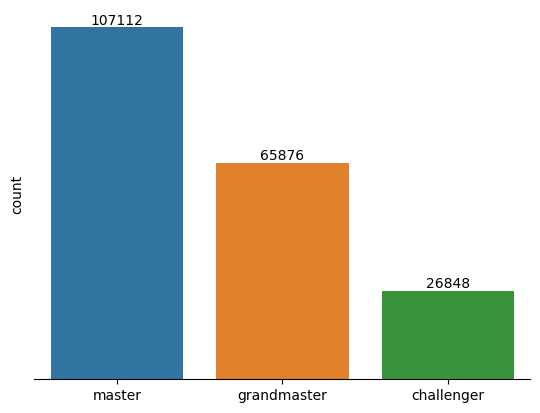

```python
# A simple seaborn bar chart that counts the number of whatever column you choose, from whatever dataframe you choose
ax = sb.countplot(x='rank', data=df)
# Annotates bar plots with the aggregates counts from the column we specified
ax.bar_label(ax.containers[0])

# Hiding what I don't want to see

# Hides the top bar
ax.spines['top'].set_visible(False)
# Hides the left bar
ax.spines['left'].set_visible(False)
# Hides the right bar
ax.spines['right'].set_visible(False)
# Hides the Y axis ticks - which we don't need since we labeled the bars
plt.yticks([])
# Hides the X axis label - which we don't need since the bars clear show what they are
plt.xlabel('')

# Show the plot
plt.show()
```

> We can see that we have fewer games the higher the rank. This is to be expected as it is more and more difficult to climb to a higher rank.

### 2. Does blue or red side win more often?

[figure not shown]

```python
# A simple seaborn bar chart that counts the number of whatever column you choose, from whatever dataframe you choose
ax = sb.countplot(x='blueWins', data=df)
# Annotates bar plots with the aggregates counts from the column we specified
ax.bar_label(ax.containers[0])
# Adds a title
ax.set_title('Number of time Blue Side Won', fontdict={'size': 13, 'weight': 'semibold'})

# Hiding what I don't want to see

# Hides the top bar
ax.spines['top'].set_visible(False)
# Hides the left bar
ax.spines['left'].set_visible(False)
# Hides the right bar
ax.spines['right'].set_visible(False)
# Hides the Y axis ticks - which we don't need since we labeled the bars
plt.yticks([])
# Hides the X axis label - which we don't need since the bars clear show what they are
plt.xlabel('')

# Show the plot
plt.show()
```

> We can see that overall, the red side wins slightly more often than the blue side.

### 3. Does blue or red side get first blood more often?

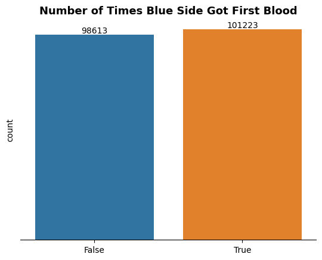

```python
# A simple seaborn bar chart that counts the number of whatever column you choose, from whatever dataframe you choose
ax = sb.countplot(x='blueFirstBlood', data=df)
# Annotates bar plots with the aggregates counts from the column we specified
ax.bar_label(ax.containers[0])
# Adds a title
ax.set_title('Number of Times Blue Side Got First Blood', fontdict={'size': 13, 'weight': 'semibold'})

# Hiding what I don't want to see

# Hides the top bar
ax.spines['top'].set_visible(False)
# Hides the left bar
ax.spines['left'].set_visible(False)
# Hides the right bar
ax.spines['right'].set_visible(False)
# Hides the Y axis ticks - which we don't need since we labeled the bars
plt.yticks([])
# Hides the X axis label - which we don't need since the bars clear show what they are
plt.xlabel('')

# Show the plot
plt.show()
```

> Blue side gets first blood more often.

### 4. Does blue or red side get first tower more often?

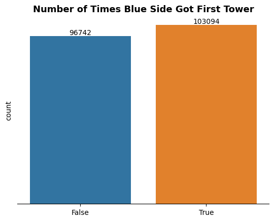

```python
# A simple seaborn bar chart that counts the number of whatever column you choose, from whatever dataframe you choose
ax = sb.countplot(x='blueFirstTower', data=df)
# Annotates bar plots with the aggregates counts from the column we specified
ax.bar_label(ax.containers[0])
# Adds a title
ax.set_title('Number of Times Blue Side Got First Tower', fontdict={'size': 13, 'weight': 'semibold'})

# Hiding what I don't want to see

# Hides the top bar
ax.spines['top'].set_visible(False)
# Hides the left bar
ax.spines['left'].set_visible(False)
# Hides the right bar
ax.spines['right'].set_visible(False)
# Hides the Y axis ticks - which we don't need since we labeled the bars
plt.yticks([])
# Hides the X axis label - which we don't need since the bars clear show what they are
plt.xlabel('')

# Show the plot
plt.show()
```

> Blue side gets first tower more often.

### 5. Does blue or red side get first dragon more often?

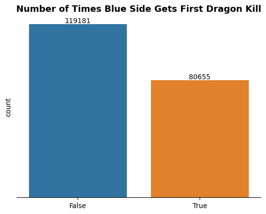

```python
# A simple seaborn bar chart that counts the number of whatever column you choose, from whatever dataframe you choose
ax = sb.countplot(x='blueFirstDragon', data=df)
# Annotates bar plots with the aggregates counts from the column we specified
ax.bar_label(ax.containers[0])
# Adds a title
ax.set_title('Number of Times Blue Side Gets First Dragon Kill', fontdict={'size': 13, 'weight': 'semibold'})

# Hiding what I don't want to see

# Hides the top bar
ax.spines['top'].set_visible(False)
# Hides the left bar
ax.spines['left'].set_visible(False)
# Hides the right bar
ax.spines['right'].set_visible(False)
# Hides the Y axis ticks - which we don't need since we labeled the bars
plt.yticks([])
# Hides the X axis label - which we don't need since the bars clear show what they are
plt.xlabel('')

# Show the plot
plt.show()
```

> Red side gets the first dragon kill markedly more often than blue side.

### 6. Does blue or red side get first baron more often?

> Baron is an optional in-game objective that doesn't show up until 20 minutes. It is therefore entirely possible that neither blue nor red side will have taken baron by the end of the game. Therefore, let's filter for only the games were either blue or red side took baron.

```python
df_baron = df[(df['blueFirstBaron'] == True) | (df['redFirstBaron'] == True)]
```

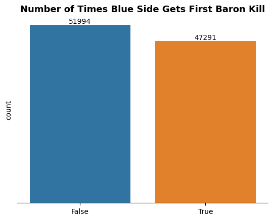

```python
# A simple seaborn bar chart that counts the number of whatever column you choose, from whatever dataframe you choose
ax = sb.countplot(x='blueFirstBaron', data=df_baron)
# Annotates bar plots with the aggregates counts from the column we specified
ax.bar_label(ax.containers[0])
# Adds a title
ax.set_title('Number of Times Blue Side Gets First Baron Kill', fontdict={'size': 13, 'weight': 'semibold'})

# Hiding what I don't want to see

# Hides the top bar
ax.spines['top'].set_visible(False)
# Hides the left bar
ax.spines['left'].set_visible(False)
# Hides the right bar
ax.spines['right'].set_visible(False)
# Hides the Y axis ticks - which we don't need since we labeled the bars
plt.yticks([])
# Hides the X axis label - which we don't need since the bars clear show what they are
plt.xlabel('')

# Show the plot
plt.show()
```

> Red side gets the first baron kill more often than blue side does.

### 7. Does blue or red side get first inhibitor more often?

> We are using df2 (games that are 15 minutes or longer) because an inhibitor needs to be destroyed in order to win the game, but it is possible that none are destroyed in games were players disconnected or left early thus ending the game earlier.

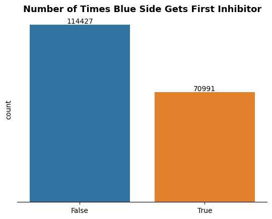

```python
# A simple seaborn bar chart that counts the number of whatever column you choose, from whatever dataframe you choose
ax = sb.countplot(x='blueFirstInhibitor', data=df2)
# Annotates bar plots with the aggregates counts from the column we specified
ax.bar_label(ax.containers[0])
# Adds a title
ax.set_title('Number of Times Blue Side Gets First Inhibitor', fontdict={'size': 13, 'weight': 'semibold'})

# Hiding what I don't want to see

# Hides the top bar
ax.spines['top'].set_visible(False)
# Hides the left bar
ax.spines['left'].set_visible(False)
# Hides the right bar
ax.spines['right'].set_visible(False)
# Hides the Y axis ticks - which we don't need since we labeled the bars
plt.yticks([])
# Hides the X axis label - which we don't need since the bars clear show what they are
plt.xlabel('')

# Show the plot
plt.show()
```

> Red side gets the first inhibitor significantly more often than blue side does.

### 8. What does the game duration look like?

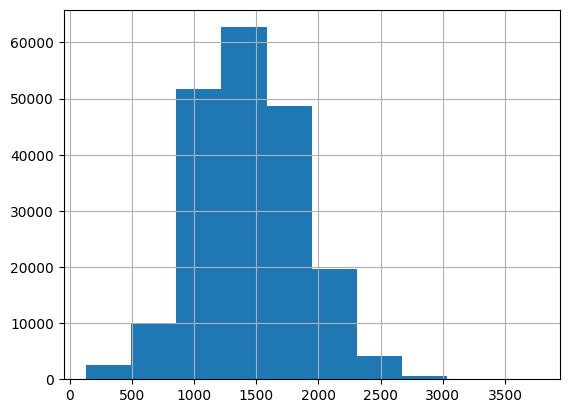

```python
df.gameDuraton.hist()
```

> Seeing game duration in seconds doesn't give us a good idea of what we're looking at. Let's look at it in minutes instead.

```python
df['game_duration_minutes']=df.apply(lambda x: x['gameDuraton']/60, axis=1)
```

```python
df['game_duration_minutes']
```

```
0         23.816667
1         21.883333
2         27.666667
3         16.400000
4         23.950000
            ...
199831    24.466667
199832    16.166667
199833    24.666667
199834    30.616667
199835    15.800000
Name: game_duration_minutes, Length: 199836, dtype: float64
```

```python
df.game_duration_minutes.describe()
```

```
count    199836.000000
mean         23.890245
std           7.208262
min           2.200000
25%          18.750000
50%          23.666667
75%          28.866667
max          62.633333
Name: game_duration_minutes, dtype: float64
```

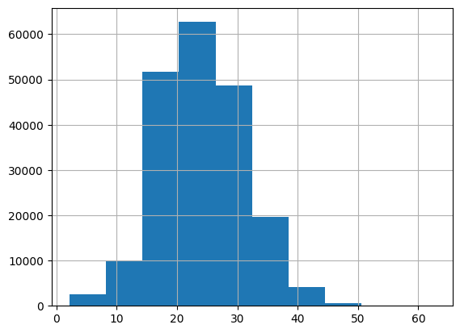

```python
df.game_duration_minutes.hist()
```

> Most games fall between the 20 and 30 minute mark. We know that the option to surrender only shows up at the 15 minute mark. Games that end before the 15 minute mark are an indication that a player was unable to load into the game or that a player left the game early, giving their teammates the option to end the game early.

> Let's copy our dataframe and in our copy drop rows with games under 15 minutes, so we can later analyze games that were played out seperately from those that weren't.

```python
df2 = df.copy()
```

```python
df2 = df2[df2.game_duration_minutes >15]
```

```python
df2.game_duration_minutes.describe()
```

```
count    185418.000000
mean         24.893533
std           6.398412
min          15.016667
25%          20.087500
50%          24.366667
75%          29.266667
max          62.633333
Name: game_duration_minutes, dtype: float64
```

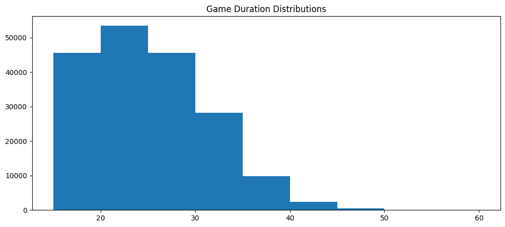

```python
# Using a simple matplotlib graph.

# State how big (in inches) the graph should be.
plt.figure(figsize=(12,5))
# Creates bins that will show across the x axis. We start at 15 and end at 65 because we know our data falls within this range.
bins = np.arange(15, 65, 5)

# Stating we want a histogram and where to grab the bins from.
plt.hist(df2.game_duration_minutes, bins=bins)
# Adding a title to our graph.
plt.title('Game Duration Distributions')
```

### 9. What does total gold look like?

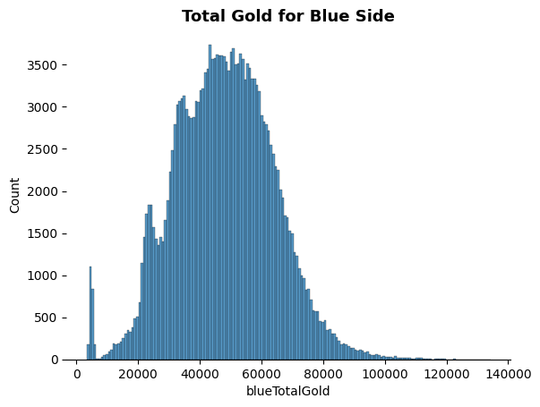

```python
# A seaborn histogram that counts the number of whatever column you choose, from whatever dataframe you choose
ax = sb.histplot(x='blueTotalGold', data=df)
# Adds a title
ax.set_title('Total Gold for Blue Side', fontdict={'size': 13, 'weight': 'semibold'})

# Hiding what I don't want to see

# Hides the top bar
ax.spines['top'].set_visible(False)
# Hides the left bar
ax.spines['left'].set_visible(False)
# Hides the right bar
ax.spines['right'].set_visible(False)

# Show the plot
plt.show()
```

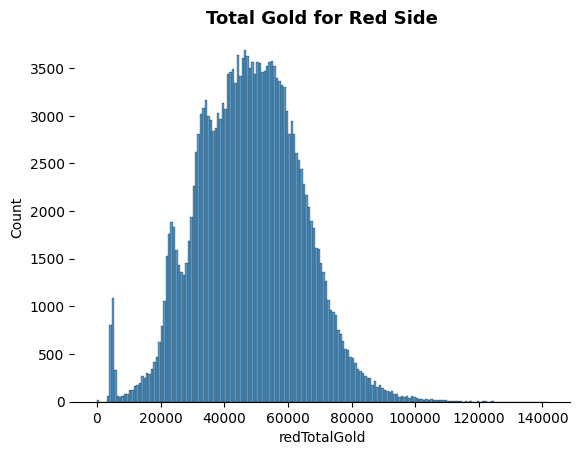

```python
# A seaborn histogram that counts the number of whatever column you choose, from whatever dataframe you choose
ax = sb.histplot(x='redTotalGold', data=df)
# Adds a title
ax.set_title('Total Gold for Red Side', fontdict={'size': 13, 'weight': 'semibold'})

# Hiding what I don't want to see

# Hides the top bar
ax.spines['top'].set_visible(False)
# Hides the left bar
ax.spines['left'].set_visible(False)
# Hides the right bar
ax.spines['right'].set_visible(False)

# Show the plot
plt.show()
```

> Upon a first look both sides appear to have similar patterns in total gold.

### Discuss the distribution(s) of your variable(s) of interest. Were there any unusual points? Did you need to perform any transformations?

> I discovered that red side wins only slightly more often, but gets the first dragon kill, first baron kill, and first inhibitor much more often than blue side. Blue side gets first blood and first tower more often than red side. There are also significantly fewer games the higher the rank, which is expected given the increased difficulty of the games with each rank.

### Of the features you investigated, were there any unusual distributions? Did you perform any operations on the data to tidy, adjust, or change the form of the data? If so, why did you do this?

> I created a column that allowed me to see the game duration in minutes. I also created a copy of the dataframe and dropped rows with games less than 15 minutes. I did this because the option to forfeit doesn't appear until 15 minutes into the game, which means games that end before the 15 minute mark are indicative of a player who either was unable to connect or that left the game early. I believe it's important to analyze games in two categories, those who did not get played all the way through and those that did. Unfortunately, we don't have information for whether a game was forfeited or not, so I use 15 minutes as the distinguishing mark.

## Bivariate Exploration

### 1. Does blue or red win more often in each rank?

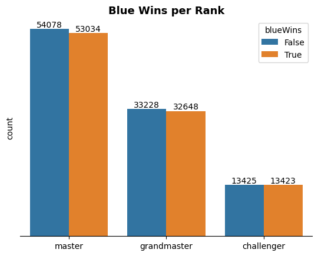

```python
# A simple seaborn bar chart that counts the number of whatever column you choose, from whatever dataframe you choose
ax = sb.countplot(x='rank',  hue='blueWins', data=df)
# Annotates bar plots with the aggregates counts from the column we specified. Must loop to iterate through the list of labels.
for i in ax.containers:
    ax.bar_label(i,)
# Adds a title
ax.set_title('Blue Wins per Rank', fontdict={'size': 13, 'weight': 'semibold'})

# Hiding what I don't want to see

# Hides the top bar
ax.spines['top'].set_visible(False)
# Hides the left bar
ax.spines['left'].set_visible(False)
# Hides the right bar
ax.spines['right'].set_visible(False)
# Hides the Y axis ticks - which we don't need since we labeled the bars
plt.yticks([])
# Hides the X axis label - which we don't need since the bars clear show what they are
plt.xlabel('')

# Show the plot
plt.show()
```

> Regardless of rank, red side wins slightly more often than blue side.

### 2. Does blue or red side get first blood more often in each rank?

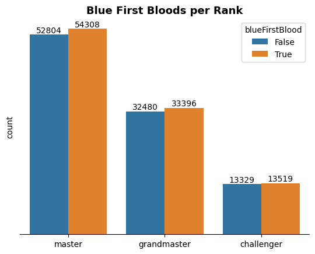

```python
# A simple seaborn bar chart that counts the number of whatever column you choose, from whatever dataframe you choose
ax = sb.countplot(x='rank',  hue='blueFirstBlood', data=df)
# Annotates bar plots with the aggregates counts from the column we specified. Must loop to iterate through the list of labels.
for i in ax.containers:
    ax.bar_label(i,)
# Adds a title
ax.set_title('Blue First Bloods per Rank', fontdict={'size': 13, 'weight': 'semibold'})

# Hiding what I don't want to see

# Hides the top bar
ax.spines['top'].set_visible(False)
# Hides the left bar
ax.spines['left'].set_visible(False)
# Hides the right bar
ax.spines['right'].set_visible(False)
# Hides the Y axis ticks - which we don't need since we labeled the bars
plt.yticks([])
# Hides the X axis label - which we don't need since the bars clear show what they are
plt.xlabel('')

# Show the plot
plt.show()
```

> Regardless of rank, blue side gets first blood more often than red side.

### 3. Does blue or red side get first tower more often in each rank?

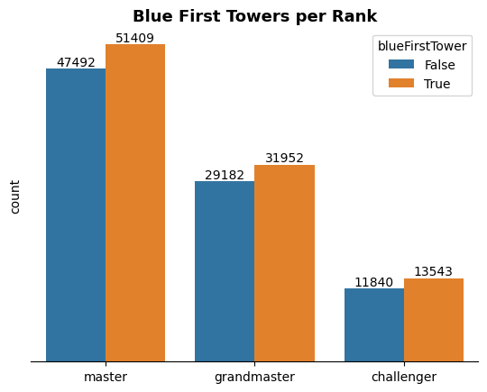

```python
# A simple seaborn bar chart that counts the number of whatever column you choose, from whatever dataframe you choose
ax = sb.countplot(x='rank',  hue='blueFirstTower', data=df2)
# Annotates bar plots with the aggregates counts from the column we specified. Must loop to iterate through the list of labels.
for i in ax.containers:
    ax.bar_label(i,)
# Adds a title
ax.set_title('Blue First Towers per Rank', fontdict={'size': 13, 'weight': 'semibold'})

# Hiding what I don't want to see

# Hides the top bar
ax.spines['top'].set_visible(False)
# Hides the left bar
ax.spines['left'].set_visible(False)
# Hides the right bar
ax.spines['right'].set_visible(False)
# Hides the Y axis ticks - which we don't need since we labeled the bars
plt.yticks([])
# Hides the X axis label - which we don't need since the bars clear show what they are
plt.xlabel('')

# Show the plot
plt.show()
```

> Regardless of rank, blue side gets first tower more often.

### 4. Does blue or red side get first dragon more often in each rank?

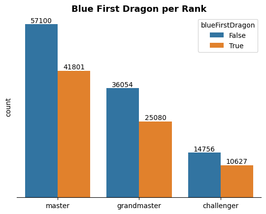

```python
# A simple seaborn bar chart that counts the number of whatever column you choose, from whatever dataframe you choose
ax = sb.countplot(x='rank',  hue='blueFirstDragon', data=df2)
# Annotates bar plots with the aggregates counts from the column we specified. Must loop to iterate through the list of labels.
for i in ax.containers:
    ax.bar_label(i,)
# Adds a title
ax.set_title('Blue First Dragon per Rank', fontdict={'size': 13, 'weight': 'semibold'})

# Hiding what I don't want to see

# Hides the top bar
ax.spines['top'].set_visible(False)
# Hides the left bar
ax.spines['left'].set_visible(False)
# Hides the right bar
ax.spines['right'].set_visible(False)
# Hides the Y axis ticks - which we don't need since we labeled the bars
plt.yticks([])
# Hides the X axis label - which we don't need since the bars clear show what they are
plt.xlabel('')

# Show the plot
plt.show()
```

### 5. Does blue or red side get first baron more often in each rank?

> Again, as stated earlier, baron is optional. So we will again be using the dataframe we created earlier.

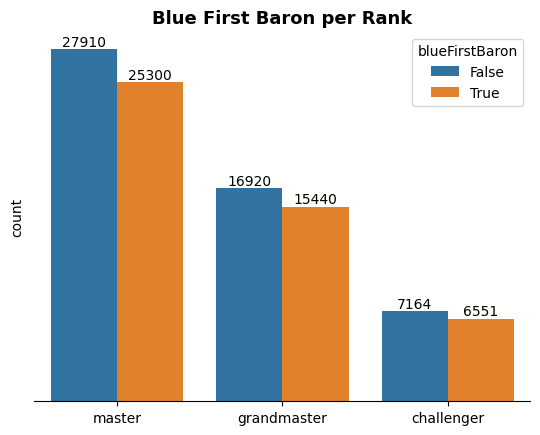

```python
# A simple seaborn bar chart that counts the number of whatever column you choose, from whatever dataframe you choose
ax = sb.countplot(x='rank',  hue='blueFirstBaron', data=df_baron)
# Annotates bar plots with the aggregates counts from the column we specified. Must loop to iterate through the list of labels.
for i in ax.containers:
    ax.bar_label(i,)
# Adds a title
ax.set_title('Blue First Baron per Rank', fontdict={'size': 13, 'weight': 'semibold'})

# Hiding what I don't want to see

# Hides the top bar
ax.spines['top'].set_visible(False)
# Hides the left bar
ax.spines['left'].set_visible(False)
# Hides the right bar
ax.spines['right'].set_visible(False)
# Hides the Y axis ticks - which we don't need since we labeled the bars
plt.yticks([])
# Hides the X axis label - which we don't need since the bars clear show what they are
plt.xlabel('')

# Show the plot
plt.show()
```

> In all ranks, red side gets the first baron kill more often than blue side.

### 6. Does blue or red side get first inhibitor more often in each rank?

> It is necessary to destroy the inhibitor in order to win the game. Thus, we are again using df2 (games that are 15 minutes or longer)

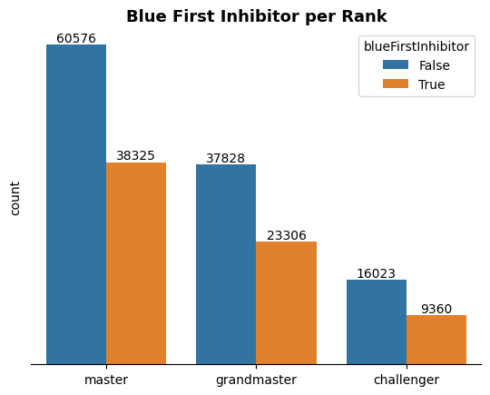

```python
# A simple seaborn bar chart that counts the number of whatever column you choose, from whatever dataframe you choose
ax = sb.countplot(x='rank',  hue='blueFirstInhibitor', data=df2)
# Annotates bar plots with the aggregates counts from the column we specified. Must loop to iterate through the list of labels.
for i in ax.containers:
    ax.bar_label(i,)
# Adds a title
ax.set_title('Blue First Inhibitor per Rank', fontdict={'size': 13, 'weight': 'semibold'})

# Hiding what I don't want to see

# Hides the top bar
ax.spines['top'].set_visible(False)
# Hides the left bar
ax.spines['left'].set_visible(False)
# Hides the right bar
ax.spines['right'].set_visible(False)
# Hides the Y axis ticks - which we don't need since we labeled the bars
plt.yticks([])
# Hides the X axis label - which we don't need since the bars clear show what they are
plt.xlabel('')

# Show the plot
plt.show()
```

### 7. What does game duration look like in each rank?

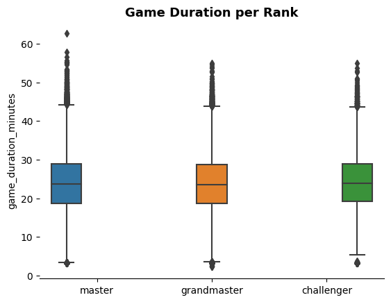

```python
# A seaborn grouped boxplot
ax = sb.boxplot(x="rank", y="game_duration_minutes",
            hue="rank",
            data=df)
# Adds a title
ax.set_title('Game Duration per Rank', fontdict={'size': 13, 'weight': 'semibold'})

# Hiding what I don't want to see

# Hides the top bar
ax.spines['top'].set_visible(False)
# Hides the left bar
ax.spines['left'].set_visible(False)
# Hides the right bar
ax.spines['right'].set_visible(False)
# Hides the X axis label - which we don't need since the bars clear show what they are
plt.xlabel('')
# Hides the legend - which we don't need since there are only two variables and they are both clearly labeled
plt.legend([],[], frameon=False)

# Show the plot
plt.show()
```

### 8. What does total gold look like in each rank?

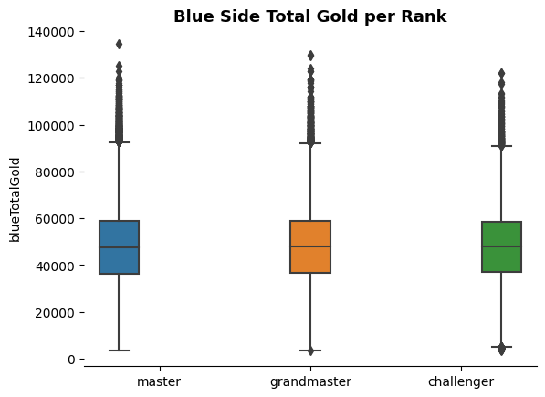

```python
# A seaborn grouped boxplot
ax = sb.boxplot(x="rank", y="blueTotalGold",
            hue="rank",
            data=df)
# Adds a title
ax.set_title('Blue Side Total Gold per Rank', fontdict={'size': 13, 'weight': 'semibold'})

# Hiding what I don't want to see

# Hides the top bar
ax.spines['top'].set_visible(False)
# Hides the left bar
ax.spines['left'].set_visible(False)
# Hides the right bar
ax.spines['right'].set_visible(False)
# Hides the X axis label - which we don't need since the bars clear show what they are
plt.xlabel('')
# Hides the legend - which we don't need since there are only two variables and they are both clearly labeled
plt.legend([],[], frameon=False)

# Show the plot
plt.show()
```

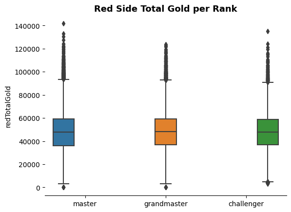

```python
# A seaborn grouped boxplot
ax = sb.boxplot(x="rank", y="redTotalGold",
            hue="rank",
            data=df)
# Adds a title
ax.set_title('Red Side Total Gold per Rank', fontdict={'size': 13, 'weight': 'semibold'})

# Hiding what I don't want to see

# Hides the top bar
ax.spines['top'].set_visible(False)
# Hides the left bar
ax.spines['left'].set_visible(False)
# Hides the right bar
ax.spines['right'].set_visible(False)
# Hides the X axis label - which we don't need since the bars clear show what they are
plt.xlabel('')
# Hides the legend - which we don't need since there are only two variables and they are both clearly labeled
plt.legend([],[], frameon=False)

# Show the plot
plt.show()
```

### 9. What do wards placed look like in each rank?

> Wards are currently split up into the amount placed by the red side and the amount placed by the blue side. Let's create a column to total the number wards placed in each game so we can analyze that number per rank.

```python
df['total_wards_placed']= df['blueWardPlaced']+df['redWardPlaced']
```

```python
df['total_wards_placed'].describe()
```

```
count    199836.000000
mean        106.996983
std          59.405396
min           0.000000
25%          67.000000
50%         108.000000
75%         146.000000
max         412.000000
Name: total_wards_placed, dtype: float64
```

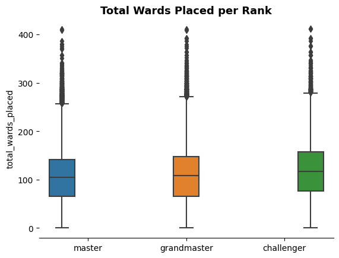

```python
# A seaborn grouped boxplot
ax = sb.boxplot(x="rank", y="total_wards_placed",
            hue="rank",
            data=df)
# Adds a title
ax.set_title('Total Wards Placed per Rank', fontdict={'size': 13, 'weight': 'semibold'})

# Hiding what I don't want to see

# Hides the top bar
ax.spines['top'].set_visible(False)
# Hides the left bar
ax.spines['left'].set_visible(False)
# Hides the right bar
ax.spines['right'].set_visible(False)
# Hides the X axis label - which we don't need since the bars clear show what they are
plt.xlabel('')
# Hides the legend - which we don't need since there are only two variables and they are both clearly labeled
plt.legend([],[], frameon=False)

# Show the plot
plt.show()
```

> There are more wards placed per game the higher in rank the game is.

### 10. What do wards killed look like in each rank?

> Ward killed are currently split up into the amount killed by the red side and the amount killed by the blue side. Let's create a column to total the number wards placed in each game so we can analyze that number per rank.

```python
df['total_wards_killed']= df['blueWardkills']+df['redWardkills']
```

```python
df['total_wards_killed'].describe()
```

```
count    199836.00000
mean         38.76816
std          28.03373
min           0.00000
25%          17.00000
50%          36.00000
75%          57.00000
max         226.00000
Name: total_wards_killed, dtype: float64
```

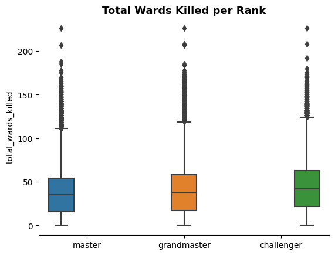

```python
# A seaborn grouped boxplot
ax = sb.boxplot(x="rank", y="total_wards_killed",
            hue="rank",
            data=df)
# Adds a title
ax.set_title('Total Wards Killed per Rank', fontdict={'size': 13, 'weight': 'semibold'})

# Hiding what I don't want to see

# Hides the top bar
ax.spines['top'].set_visible(False)
# Hides the left bar
ax.spines['left'].set_visible(False)
# Hides the right bar
ax.spines['right'].set_visible(False)
# Hides the X axis label - which we don't need since the bars clear show what they are
plt.xlabel('')
# Hides the legend - which we don't need since there are only two variables and they are both clearly labeled
plt.legend([],[], frameon=False)

# Show the plot
plt.show()
```

> There are more wards killed per game the higher in rank the game is.

### 11. What do wards placed look like in comparison to if the game was won or not?

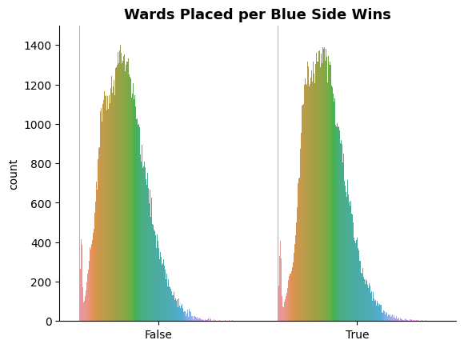

```python
# A simple seaborn bar chart that counts the number of whatever column you choose, from whatever dataframe you choose
ax = sb.countplot(x='blueWins',  hue='blueWardPlaced', data=df)
# Adds a title
ax.set_title('Wards Placed per Blue Side Wins', fontdict={'size': 13, 'weight': 'semibold'})
# Sets a max view for the y axis
ax.set_ylim(ymax=1500)

# Hiding what I don't want to see

# Hides the top bar
ax.spines['top'].set_visible(False)
# Hides the right bar
ax.spines['right'].set_visible(False)
# Hides the X axis label - which we don't need since the bars clear show what they are
plt.xlabel('')
# Hides the legend - which we don't need since there are only two variables and they are both clearly labeled
plt.legend([],[], frameon=False)

# Show the plot
plt.show()
```

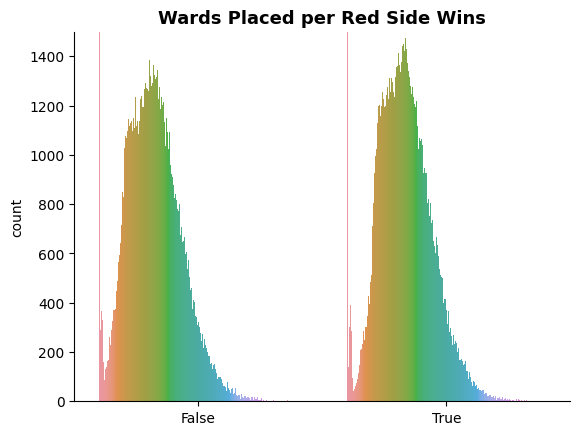

```python
# A simple seaborn bar chart that counts the number of whatever column you choose, from whatever dataframe you choose
ax = sb.countplot(x='redWins',  hue='redWardPlaced', data=df)
# Adds a title
ax.set_title('Wards Placed per Red Side Wins', fontdict={'size': 13, 'weight': 'semibold'})
# Sets a max view for the y axis
ax.set_ylim(ymax=1500)

# Hiding what I don't want to see

# Hides the top bar
ax.spines['top'].set_visible(False)
# Hides the right bar
ax.spines['right'].set_visible(False)
# Hides the X axis label - which we don't need since the bars clear show what they are
plt.xlabel('')
# Hides the legend - which we don't need since there are only two variables and they are both clearly labeled
plt.legend([],[], frameon=False)

# Show the plot
plt.show()
```

> It would appear that for both blue and red sides, the games are more likely to have a higher number of wards placed if the game was won.

### 12. How does game duration affect wards placed?

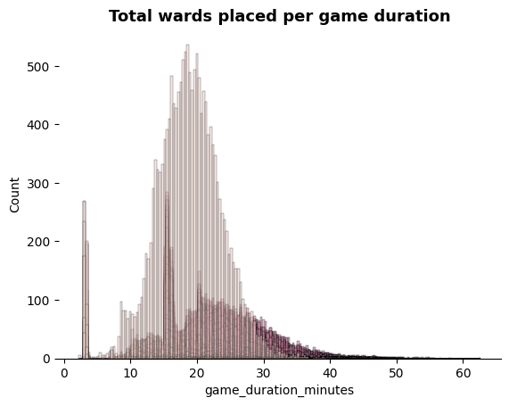

```python
# A seaborn histogram that counts the number of whatever column you choose, from whatever dataframe you choose
ax = sb.histplot(x='game_duration_minutes', hue = 'total_wards_placed', data=df)
# Adds a title
ax.set_title('Total wards placed per game duration', fontdict={'size': 13, 'weight': 'semibold'})

# Hiding what I don't want to see

# Hides the top bar
ax.spines['top'].set_visible(False)
# Hides the left bar
ax.spines['left'].set_visible(False)
# Hides the right bar
ax.spines['right'].set_visible(False)
# Hides the legend - which we don't need since there are only two variables and they are both clearly labeled
plt.legend([],[], frameon=False)

# Show the plot
plt.show()
```

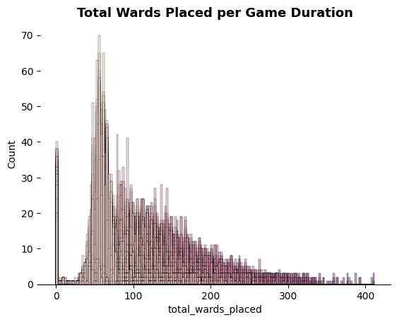

```python
# A seaborn histogram that counts the number of whatever column you choose, from whatever dataframe you choose
ax = sb.histplot(x='total_wards_placed', hue = 'game_duration_minutes', data=df2)
# Adds a title
ax.set_title('Total Wards Placed per Game Duration', fontdict={'size': 13, 'weight': 'semibold'})

# Hiding what I don't want to see

# Hides the top bar
ax.spines['top'].set_visible(False)
# Hides the left bar
ax.spines['left'].set_visible(False)
# Hides the right bar
ax.spines['right'].set_visible(False)
# Hides the legend - which we don't need since there are only two variables and they are both clearly labeled
plt.legend([],[], frameon=False)

# Show the plot
plt.show()
```

> It makes sense that highest peak total wards placed sits around 60-70. This is fairly low, but expected for most players. You then see another spike around 90-100 which is more common for experienced support players. For a number to be higher than that you need multiple people on the team purposely and strategically placing wards throughout the entire game.

### 13. How does game duration affect the winrate of blue/red side?

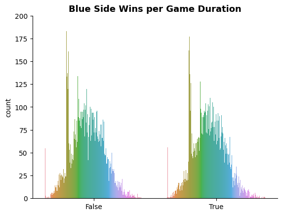

```python
# A simple seaborn bar chart that counts the number of whatever column you choose, from whatever dataframe you choose
ax = sb.countplot(x='blueWins',  hue='game_duration_minutes', data=df)
# Adds a title
ax.set_title('Blue Side Wins per Game Duration', fontdict={'size': 13, 'weight': 'semibold'})
# Sets a max view for the y axis
ax.set_ylim(ymax=200)

# Hiding what I don't want to see

# Hides the top bar
ax.spines['top'].set_visible(False)
# Hides the right bar
ax.spines['right'].set_visible(False)
# Hides the X axis label - which we don't need since the bars clear show what they are
plt.xlabel('')
# Hides the legend - which we don't need since there are only two variables and they are both clearly labeled
plt.legend([],[], frameon=False)

# Show the plot
plt.show()
```

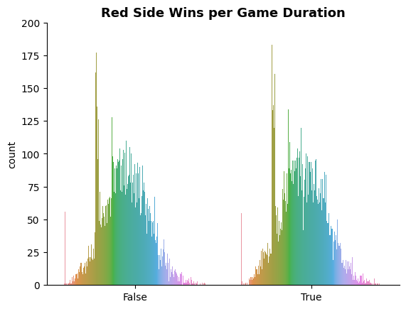

```python
# A simple seaborn bar chart that counts the number of whatever column you choose, from whatever dataframe you choose
ax = sb.countplot(x='redWins',  hue='game_duration_minutes', data=df)
# Adds a title
ax.set_title('Red Side Wins per Game Duration', fontdict={'size': 13, 'weight': 'semibold'})
# Sets a max view for the y axis
ax.set_ylim(ymax=200)

# Hiding what I don't want to see

# Hides the top bar
ax.spines['top'].set_visible(False)
# Hides the right bar
ax.spines['right'].set_visible(False)
# Hides the X axis label - which we don't need since the bars clear show what they are
plt.xlabel('')
# Hides the legend - which we don't need since there are only two variables and they are both clearly labeled
plt.legend([],[], frameon=False)

# Show the plot
plt.show()
```

> It looks like red side wins more during the early game and the late game, but blue has a little spike in the midgame.

### Talk about some of the relationships you observed in this part of the investigation. How did the feature(s) of interest vary with other features in the dataset?

> There are more wards placed and killed per game in higher ranks. Regardless of red or blue side, more wards were placed by the side that won. When taking into account game duration in minutes, there is a peak in total wards placed at 60-70, with the next spike sitting at 90-100. When analyzing red and blue side wins in relation to game duration, we see that red side wins more during the early game and the late game, but blue has a little spike in the midgame.

### Did you observe any interesting relationships between the other features (not the main feature(s) of interest)?

> Game duration added some points of interest as did looking at wards. It leads me to believe there is more to be discovered when combining these variables with others in the dataset.

## Multivariate Exploration

### 1. What is the distribution of red and blue wards in relation to game duration?

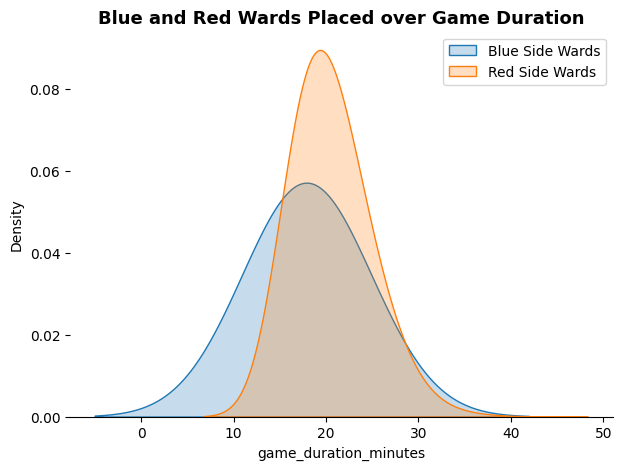

```python
# Making a kernel density estimate (KDE) plot with seaborn, similar to a histogram

# Up till now we've been able to use ax = and enter the seaborn plot directly on the same line of code
# For this plot however, since we want to plot two seperate lines that aren't connected to each other,
# we code them on seperate lines

# This code states that we want to create 1 plot on 1 axes, for a total of 1 visualization and the what the size should be
# These are super configurable parts of matplotlib
fig, ax = plt.subplots(1,1,figsize=(7,5))

# We're adding two lines, one for each of the columns we want to visualize
# This states what kind of visualization should go on the plot we created
sb.kdeplot(df2[df2['blueWardPlaced']==1]['game_duration_minutes'],ax = ax, shade=True, bw_adjust = 5)
sb.kdeplot(df2[df2['redWardPlaced']==0]['game_duration_minutes'],ax = ax, shade=True, bw_adjust = 5)

# Adds a legends that we can name specifically
plt.legend(['Blue Side Wards','Red Side Wards'])

# Adds a title
ax.set_title('Blue and Red Wards Placed over Game Duration', fontdict={'size': 13, 'weight': 'semibold'})

# Hiding what I don't want to see

# Hides the top bar
ax.spines['top'].set_visible(False)
# Hides the left bar
ax.spines['left'].set_visible(False)
# Hides the right bar
ax.spines['right'].set_visible(False)
# Hides the Y axis ticks - which we don't need since we labeled the bars
#plt.yticks([])
# Hides the X axis label - which we don't need since the bars clear show what they are
#plt.xlabel('')

# Show the plot
plt.show()
```

### 2. What do wards look like per rank in relation to game duration?

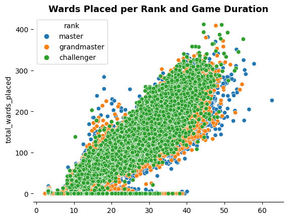

```python
# A seaborn scatterplot
ax = sb.scatterplot(x='game_duration_minutes', y='total_wards_placed', hue='rank',data=df)

# Adds a title
ax.set_title('Wards Placed per Rank and Game Duration', fontdict={'size': 13, 'weight': 'semibold'})

# Hiding what I don't want to see

# Hides the top bar
ax.spines['top'].set_visible(False)
# Hides the left bar
ax.spines['left'].set_visible(False)
# Hides the right bar
ax.spines['right'].set_visible(False)
# Hides the X axis label - which we don't need since the bars clear show what they are
plt.xlabel('')

# Show the plot
plt.show()
```

> Similar to what we've seen earlier, the range of numbers decreases the higher in rank the games get, with more total wards place, earlier in the game, the higher the rank.